### 3월/3주

#### ▶ ▣ 정당지지도 ▣

더불어민주당 38.5%, 국민의힘 39.0%, 녹색정의당 1.4%, 개혁신당 3.0%, 새로운미래 1.9%, 조국 신당 8.2%, 그 외 다른 정당 1.8%, 지지하는 정당 없다 5.4%, 잘 모르겠다 0.8%

#### ▶ ▣ 대통령 국정 수행 평가 ▣

잘하고 있다 41.4%, 잘못하고 있다 56.1%, 잘 모르겠다 2.5%

#### ☑ ▣ 총선 프레임 공감 ▣

원활한 국정수행을 뒷받침하기 위해 여당인 국민의힘에 힘을 실어 줘야 한다 40.5%, 현 정권 견제를 위해서 제1야당인 민주당에 힘을 실어 줘야 한다 45.4%, 기존 양당이 아닌 제3세력에 힘을 실어 줘야 한다 14.1%

#### ☑ ▣ 총선 1당 유력 정당 전망 ▣

더불어민주당 46.1%, 국민의힘 43.3%, 녹색정의당 1.5%, 개혁신당 1.4%, 새로운미래 1.6%, 조국혁신당 3.2%, 그 외 다른 정당 0.8%, 잘 모르겠다 2.1%

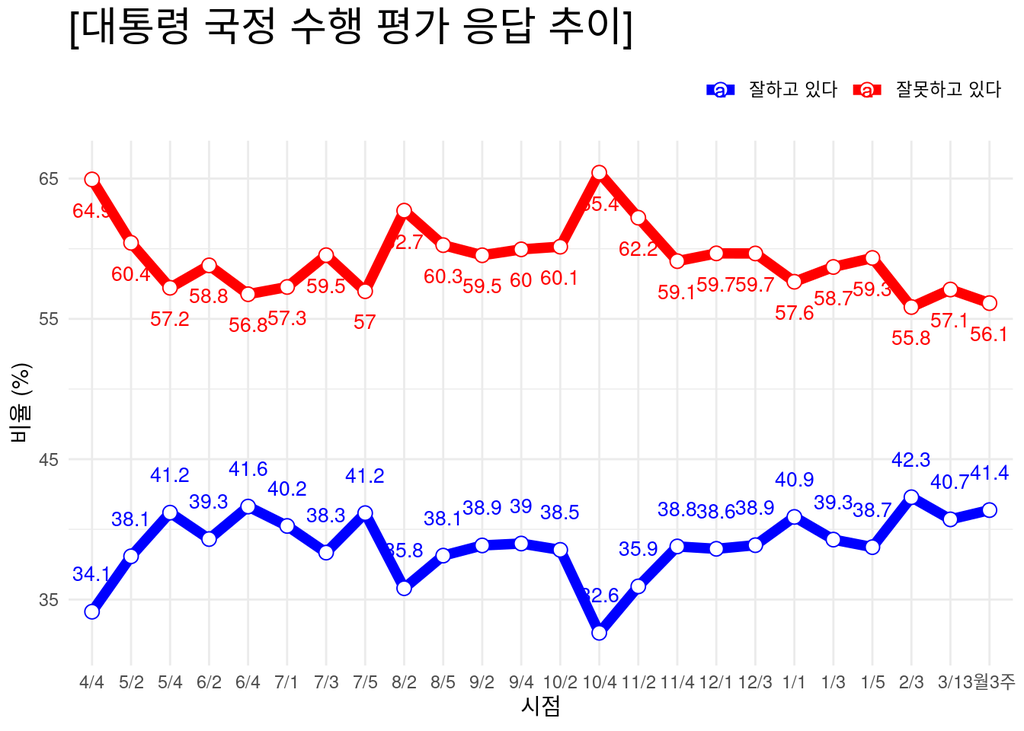

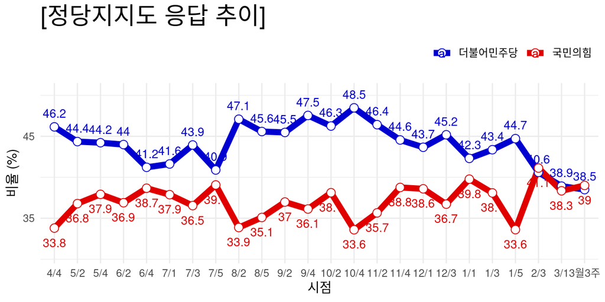

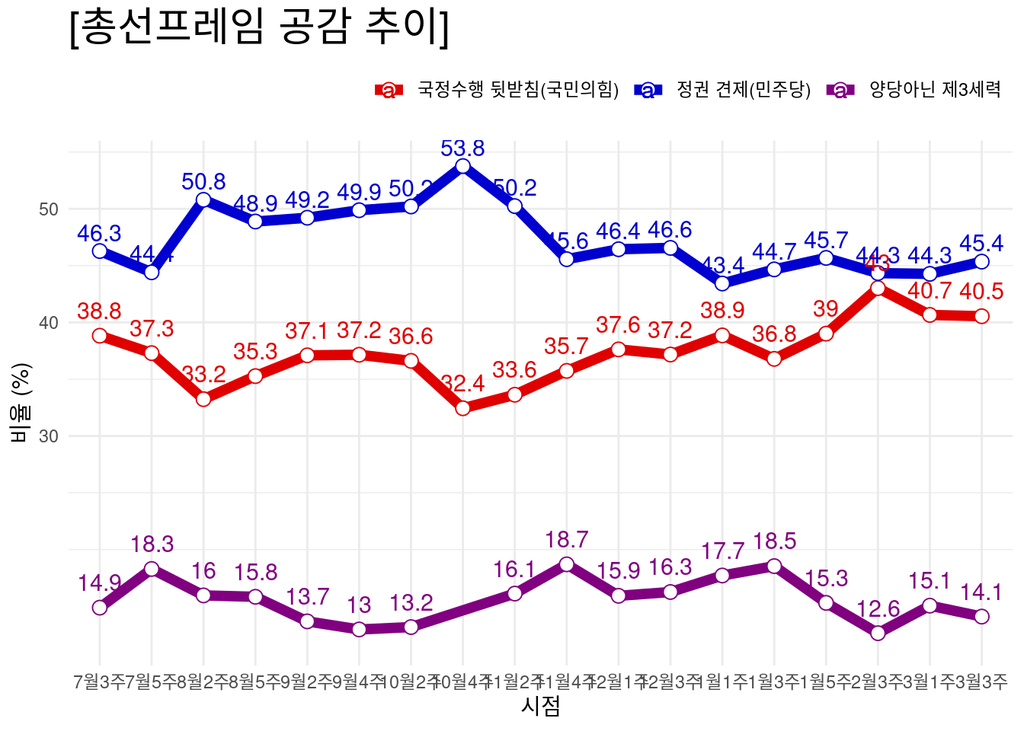

### 추가사항

- [주요질문 / 집단별 세부통계 보기](https://modernity.shinyapps.io/survey_str/) (링크누르시오)

### 참고사항

- 표본수: 2,013명,표본오차는 95% ±2.2%p
- 조사정보: 스트레이트뉴스의 의뢰로 조원씨앤아이가 2024년 3월 9일~11일 3일간

  전국 만 18세 이상 남녀를 대상으로 ARS 여론조사

  (휴대전화 100% RDD 방식, 성,연령대,지역별 비례할당 후 무작위 추출)를 실시한 결과이며,

  ※ 가중치 부여 방식: [림가중] 성별, 연령별, 지역별 가중값 부여(2024년 2월말 행정안전부 발표 주민등록인구기준)
- [중앙선거여론조사심의위원회](https://nesdc.go.kr/portal/bbs/B0000005/list.do?menuNo=200467)에서 관련사항 확인가능

2024.03.13 (Wed) 17:18 제작

- 연구개발 단계입니다.
- 제공: 감동과 마음의 [조원씨앤아이](http://jowoncni.com/html/index.html)